# Bayesian Fine-Mapping

Peter Sørensen

Center for Quantitative Genetics and Genomics, Aarhus University, Denmark

Palle Duun Rohde

Genomic Medicine, Department of Health Science and Technology, Aalborg University, Denmark

## GWAS Regions Rarely Identify a Unique Causal Variant

- A GWAS association usually identifies an **associated region**, not the causal variant.
- Because nearby SNPs are correlated through **linkage disequilibrium (LD)**, several SNPs can show strong association even when only one is causal.
- Fine-mapping tries to move from

$$\text{associated region}
\quad\longrightarrow\quad
\text{small set of plausible causal variants}.$$

- The goal is not simply to identify the most significant SNP, but to quantify which variants remain plausible causal explanations of the association signal.

## Fine-Mapping Connects Association Signals to Biology

- **Biological interpretation**  
  Connect associated variants to genes, regulatory elements, and molecular mechanisms.
- **Functional follow-up and target discovery**  
  Prioritize variants, genes, and pathways for experimental studies.
- **Quantifying uncertainty**  
  Distinguish one strongly supported variant from several LD-linked alternatives.
- **Integrating functional information**  
  Combine genetic evidence with eQTL, chromatin, conservation, and coding annotations.

## Standard GWAS

In a standard **genome-wide association study (GWAS)**, each SNP is tested separately for association with the phenotype.

#### Model and hypothesis

For SNP $j$, fit a separate regression:

$$y_i
=
\mu
+
x_{ij}\beta_j
+
e_i,
\qquad
e_i \sim \mathcal{N}(0,\sigma^2).$$

Test whether the SNP is associated with the phenotype:

$$H_0:\beta_j=0
\qquad\text{versus}\qquad
H_1:\beta_j\neq0.$$

Each SNP is tested **one at a time**.

#### GWAS output

For every SNP, GWAS typically reports:

- estimated effect $\widehat{\beta}_j$
- standard error $\operatorname{SE}(\widehat{\beta}_j)$
- $z$- or $t$-statistic
- $p$-value

The result is a marker-by-marker summary of **marginal association evidence**.

**Important:** GWAS identifies **associated SNPs**, not necessarily the causal SNP.

## LD Makes Multiple SNPs Look Associated

Nearby SNPs are often correlated because of **linkage disequilibrium (LD)**.

If SNP $j^\ast$ is causal,

$$y = x_{j^\ast}\beta_{j^\ast}+e,$$

then another SNP $j$ correlated with the causal SNP,

$$\operatorname{Cor}(x_j,x_{j^\ast})\neq0,$$

can also show a strong marginal GWAS association even when

$$\beta_j=0.$$
A GWAS peak therefore often identifies an **associated region rather than a unique causal variant**.

## LD Explains the Cluster of Marginal Associations

The same 30-SNP region is shown through its LD structure and marginal GWAS results. The simulated causal SNP is marked in red.

#### LD with the causal SNP

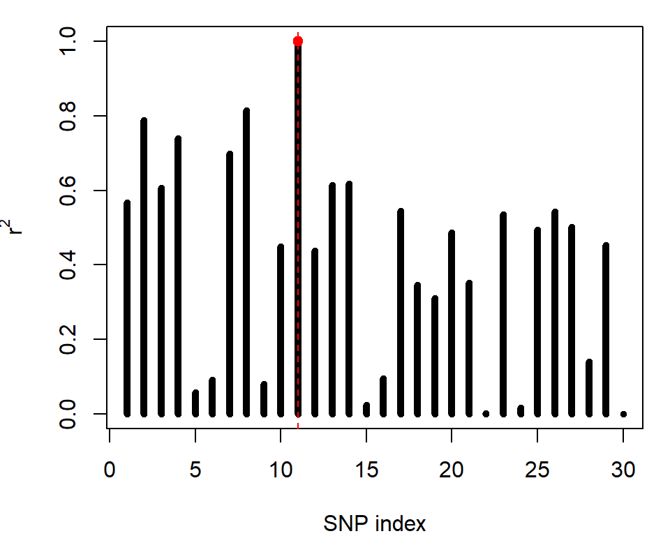

#### Marginal GWAS evidence

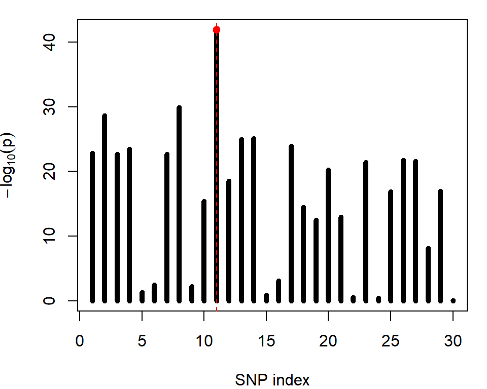

Correlated non-causal SNPs can show strong association because they tag the causal SNP.

## Fine-Mapping: Key Inputs and Outputs

Fine-mapping aims to identify which SNPs within a GWAS-associated region remain plausible causal variants after accounting for LD.

#### Key inputs

- **Marker-level association evidence**  
  e.g. marginal effect estimates $\hat{\beta}_j$ and their standard errors $\mathrm{SE}(\hat{\beta}_j)$.
- **LD between candidate SNPs**  
  represented by the LD correlation matrix, e.g. $R=\operatorname{cor}(X)$.
- **A sparse joint model for genetic effects**  
  e.g. BayesC / spike-and-slab.

#### Key outputs

- **Posterior inclusion probabilities (PIPs)**  
  Probability that each SNP has a non-zero effect.
- **Posterior effect estimates**  
  Model-averaged SNP effects.
- **Prioritized variant sets**  
  Small sets of plausible causal variants.
- **Fine-mapping uncertainty**  
  One leading SNP or several LD-linked alternatives.

Fine-mapping can use individual-level data or compatible GWAS summary statistics and external LD. Here, BayesC is illustrated using individual-level genotype and phenotype data.

## Fine-Mapping Fits SNP Effects Jointly

All SNPs are fitted **jointly**, allowing correlated SNPs to compete to explain the same association signal.

#### Model

$$y_i
=
\mu
+
\sum_{j=1}^{m}x_{ij}b_j
+
e_i,
\qquad
e_i\sim\mathcal{N}(0,\sigma_e^2).$$

In matrix form:

$$y
=
\mathbf{1}\mu
+
Xb
+
e,
\qquad
e\sim\mathcal{N}(0,\sigma_e^2I_N).$$

#### Components

- $y$ — phenotype
- $\mu$ — overall mean
- $X$ — genotype matrix
- $b$ — SNP effects
- $e$ — residual effects
- $\sigma_e^2$ — residual variance

## BayesC Makes Most SNP Effects Exactly Zero

BayesC assumes that each SNP is either **inactive** or **active**. The point mass at zero creates a **sparse model** in which many SNP effects are exactly zero.

#### Indicator and effect

Introduce an inclusion indicator:

$$d_j \in \{0,1\},
\qquad
d_j \sim \operatorname{Bernoulli}(\pi).$$

Conditional on the indicator:

$$b_j\mid(d_j=0)=0,$$

$$b_j\mid(d_j=1)
\sim
\mathcal{N}(0,\sigma_b^2).$$

#### Spike-and-slab prior

Equivalently,

$$b_j
\sim
(1-\pi)\delta_0
+
\pi\mathcal{N}(0,\sigma_b^2).$$

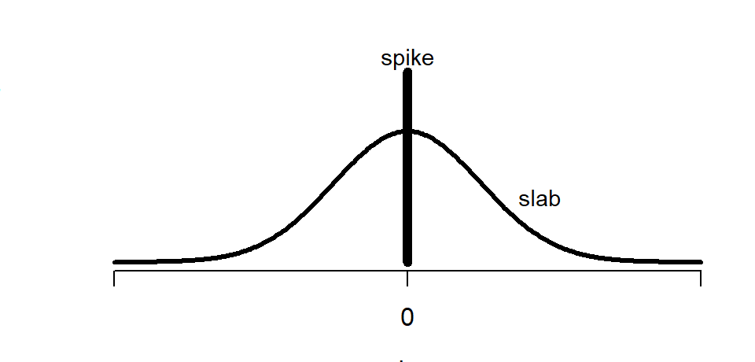

$\pi$ controls how often SNPs are active; $\sigma_b^2$ controls the variance of their non-zero effects.

## Correlated SNPs Compete Across Posterior Models

The sampler repeatedly explores possible explanations of the association signal.

#### Marker states

For every SNP $j$, it updates

$$d_j
\quad\text{and}\quad
b_j.$$

A SNP may be inactive,

$$d_j^{(t)} = 0
\qquad\Rightarrow\qquad
b_j^{(t)}=0,$$

or active,

$$d_j^{(t)} = 1
\qquad\Rightarrow\qquad
b_j^{(t)}\neq0.$$

#### Sampled inclusion states

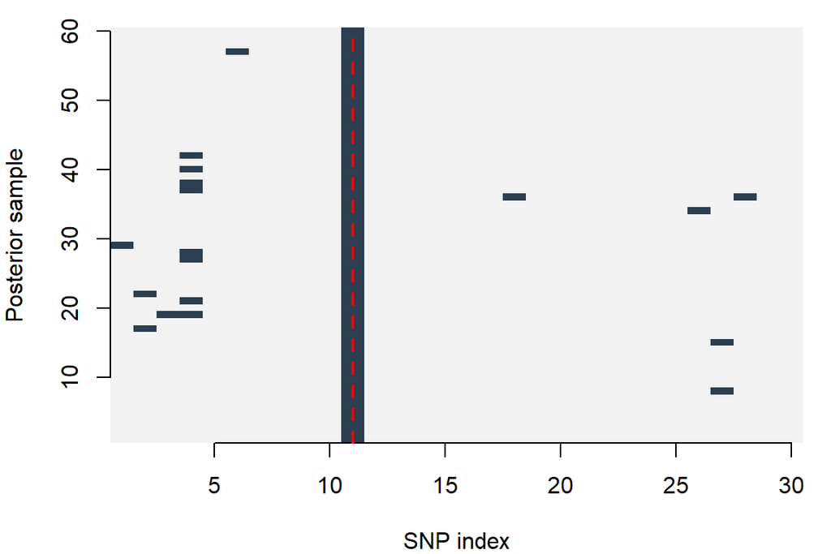

Because all SNPs are fitted jointly, correlated SNPs can alternate as explanations of the same signal.

## Posterior Samples Become Marker-Level Evidence

The MCMC samples generate two important marker-level summaries.

#### Posterior inclusion probability

$$\operatorname{PIP}_j
=
\Pr(d_j=1\mid\mathcal D)$$

estimated by

$$\widehat{\operatorname{PIP}}_j
=
\frac{1}{T}
\sum_{t=1}^{T}
d_j^{(t)}.$$

**Question answered:** How often is SNP $j$ needed in posterior models?

#### Posterior mean effect

$$\widehat b_j
=
E(b_j\mid\mathcal D)$$

estimated by

$$\widehat b_j
=
\frac{1}{T}
\sum_{t=1}^{T}
b_j^{(t)}.$$

**Question answered:** What is the estimated SNP effect after averaging across posterior models?

## Joint Modelling Redistributes the GWAS Signal

The marginal GWAS signal is compared with support from the joint BayesC model.

#### Marginal GWAS

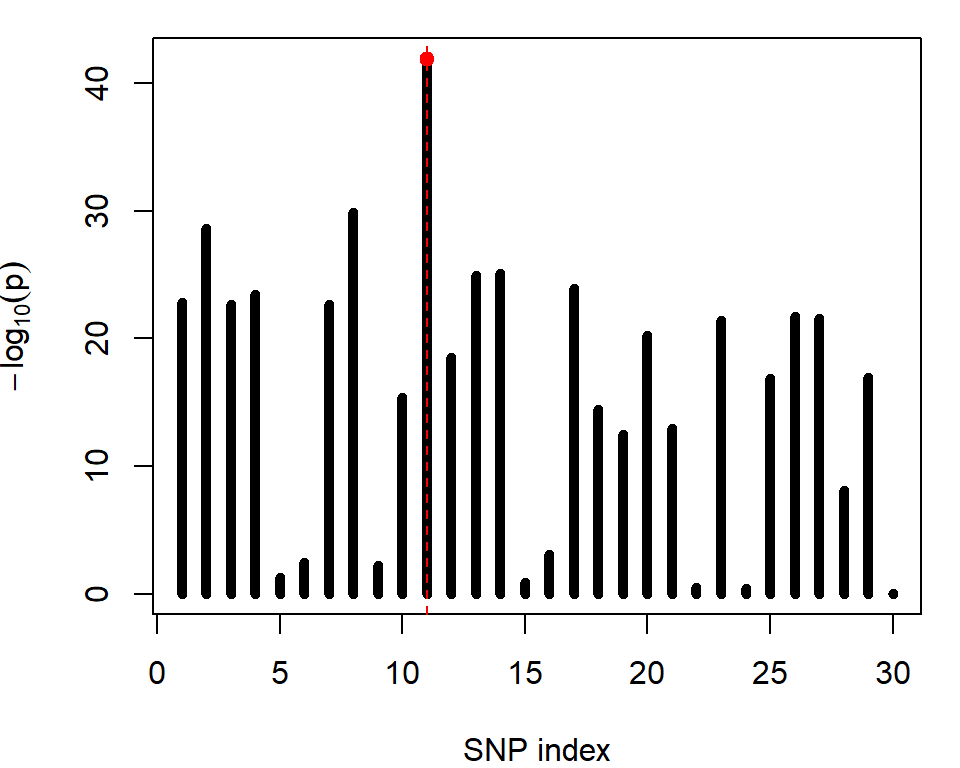

#### BayesC PIPs

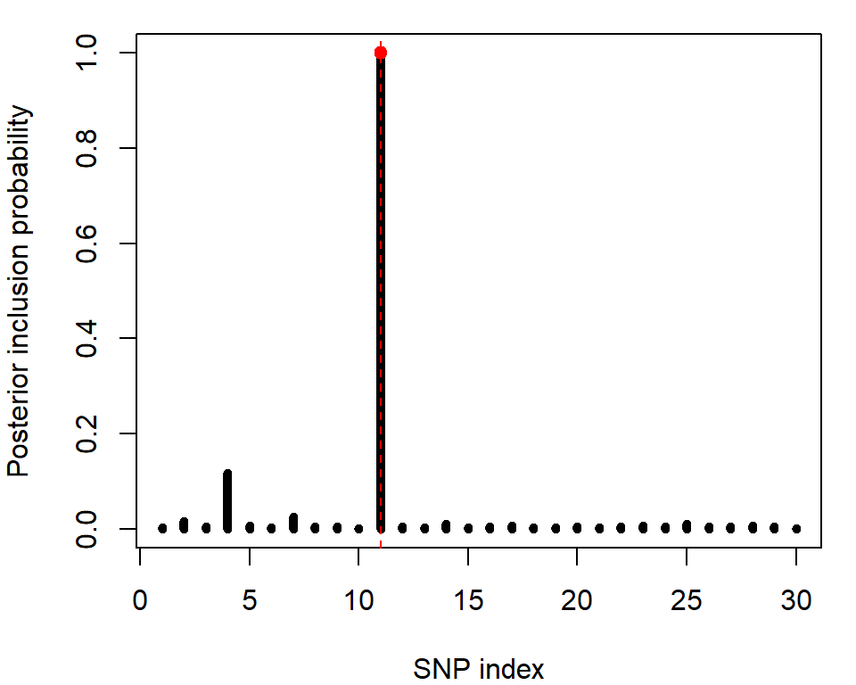

Joint modelling concentrates support on variants that remain plausible after accounting for the other SNPs and their LD.

## PIP and Effect Size Answer Different Questions

#### Posterior inclusion probability

$$\operatorname{PIP}_j
=
\Pr(b_j\neq0\mid\mathcal D).$$

Measures how often SNP $j$ is included in posterior models.

A SNP can have a **high PIP but a moderate effect** if it is frequently active with a relatively small effect.

#### Posterior mean effect

$$E(b_j\mid\mathcal D).$$

Measures the model-averaged effect of SNP $j$, including iterations in which its effect is zero.

A SNP can have a **lower PIP but large non-zero effects** when it is selected.

For fine-mapping, PIP is the main measure of support that a SNP contributes to the association signal.

## From PIPs to a Local Credible Set

A practical **local credible set (LCS)** summarizes the leading signal as a small set of plausible causal variants.

#### Construction

1. Identify the SNP with the highest PIP.
2. Select its LD neighborhood, for example

   $$r^2 \ge 0.5.$$
3. Rank these SNPs by decreasing PIP.
4. Add their PIPs until

   $$\sum_{j\in\mathcal C}\operatorname{PIP}_j
   \ge 0.90.$$

#### Interpretation

- PIPs come from the **joint model** and account for LD.
- A small LCS indicates a well-localized signal.
- A larger LCS indicates uncertainty among correlated SNPs.
- Raw PIPs are used without normalization.

Because BayesC allows multiple active SNPs, this is a **practical local summary**, not a formal $90\%$ posterior coverage set.

## Fine-Mapping Result: Local 0.9 Credible Set

#### Variants in the LCS

| marker | SNP | PIP | r2_with_focal | cumulative_PIP | causal |
| --- | --- | --- | --- | --- | --- |
| 11 | rs200766023_G | 1 | 1 | 1 | TRUE |

#### Cumulative PIP

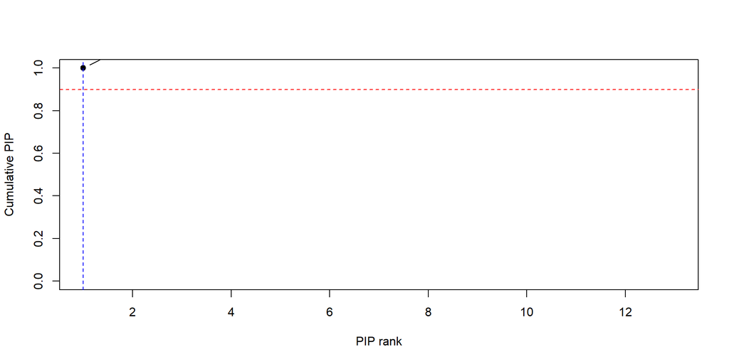

The LCS contains 1 SNPs and includes the simulated causal SNP: **yes**.

## Functional Information Can Refine Fine-Mapping

GWAS evidence and LD may leave several SNPs as plausible explanations of the same association signal.

#### Functional information

Relevant annotations include:

- coding consequence;
- regulatory annotations;
- eQTL information;
- chromatin accessibility;
- conservation;
- tissue- or cell-specific annotations.

#### Bayesian interpretation

Functional information modifies the prior evidence assigned to each SNP:

$$\text{Posterior evidence}
\propto
\text{genetic evidence}
\times
\text{prior information}.$$

It changes the **prior plausibility** of a SNP—it does not declare that SNP to be causal.

## Annotations Can Modify Two Parts of the Prior

For standard BayesC,

$$b_j \sim (1-\pi)\delta_0 + \pi \mathcal{N}(0,\sigma_b^2),$$

where all SNPs initially have the same prior inclusion probability $\pi$ and the same non-zero effect variance $\sigma_b^2$.

Annotations can make these quantities **SNP-specific**.

#### Probability architecture

Annotations modify the probability that SNP $j$ is active:

$$\pi
\quad\longrightarrow\quad
\pi_j.$$

For example,

$$P(d_j=1)=\pi_j.$$

An annotated SNP may therefore receive a larger prior probability of having a non-zero effect.

#### Variance architecture

Annotations modify the expected size of a non-zero effect:

$$\sigma_b^2
\quad\longrightarrow\quad
\sigma_{b,j}^2.$$

For example,

$$b_j\mid d_j=1
\sim
\mathcal{N}(0,\sigma_{b,j}^2).$$

An annotated SNP may therefore be allowed to have a larger prior effect variance.

## Annotations Reweight Competing Causal Explanations

Suppose two SNPs have similar statistical evidence because they are in strong LD.

#### Equal versus annotation-informed priors

Both SNPs have the same prior:

$$P(d_1=1)=P(d_2=1)=\pi.$$

If SNP 1 has a relevant functional annotation, its prior probability can increase:

$$P(d_1=1)=\pi_1,
\qquad
P(d_2=1)=\pi_2,$$

with

$$\pi_1>\pi_2.$$

#### Schematic prior reweighting

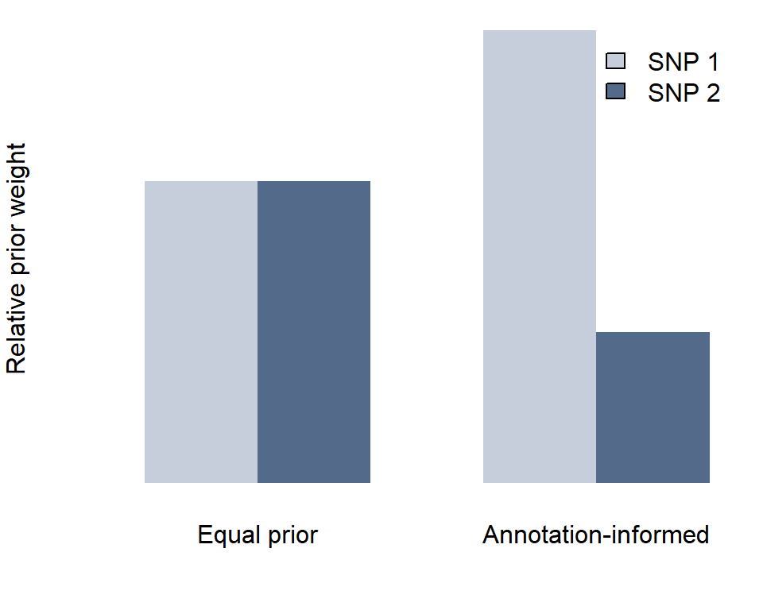

If the genetic evidence is similar, the annotation can shift posterior support toward SNP 1.

## Annotation-Informed Models Preserve the Same Workflow

The overall workflow remains the same:

$$\text{GWAS evidence}
+
\text{LD}
+
\text{prior model}
\longrightarrow
\text{posterior PIPs}.$$

With annotation-informed priors:

$$\text{GWAS evidence}
+
\text{LD}
+
\text{functional annotations}
\longrightarrow
\text{annotation-informed PIPs}.$$

The outputs are still familiar:

- posterior inclusion probabilities;
- ranked candidate SNPs;
- posterior effect estimates;
- local credible sets.

What changes is the prior assigned to each SNP—through its inclusion probability, non-zero effect variance, or both. This is the basic idea behind annotation-informed Bayesian fine-mapping models.

## Summary

- A GWAS peak usually identifies an **associated region**, not a unique causal variant.
- Fine-mapping fits SNPs jointly so that correlated variants compete to explain the signal.
- BayesC creates sparsity by modelling each SNP as either inactive or active.
- The posterior inclusion probability

  $$\operatorname{PIP}_j
  =
  \Pr(d_j=1\mid\mathcal D)$$

  quantifies the support that SNP $j$ contributes to the association signal.
- Ranked PIPs and local candidate sets summarize both prioritization and remaining uncertainty.
- Functional annotations can reweight plausible explanations, but they do not replace the genetic evidence.

## References and Further Reading

- **Wu Y, Zheng Z, Thibaut L, Lin T, Feng Q, Cheng H, Yengo L, Goddard ME, Wray NR, Visscher PM, Zeng J.**  
  Genome-wide fine-mapping improves identification of causal variants.  
  *Nature Genetics* **58**, 940–951 (2026).  
  DOI: 10.1038/s41588-026-02549-3
- **Shrestha M, Bai Z, Gholipourshahraki T, Hjelholt A, Rohde P, Fuglsang MK, Sørensen P.**  
  Enhanced genetic fine mapping accuracy with Bayesian Linear Regression models in diverse genetic architectures.  
  *PLOS Genetics* **21**(7), e1011783 (2025).  
  DOI: 10.1371/journal.pgen.1011783
- **Zheng, Z., Liu, S., Sidorenko, J. et al.**  
  Leveraging functional genomic annotations and genome coverage to improve polygenic prediction of complex traits within and between ancestries.  
  *Nature Genetics* **56**, 767–777 (2024).  
  DOI: 10.1038/s41588-024-01704-y